# Intro to Machine Learning

Richard G. Gardiner

12/11/2018

Part of this material is gathered from Laurent Gatto’s workshop on [“An Introduction to Machine Learning with R”](https://github.com/rgardiner90/IntroMachineLearning.git)

## Intro

There are two main groups of machine learning: supervised and unsupervised. Supervised machine learning (SML) is broken down into classification, where the DV is categorical, and regression, where the output is numerical. SML is closely tied with “labeled data” which means each observation has an outcome that we are trying to model.

Unsupervised machine learning (UML) is used when there are no labels provided. Algorithms take data that doesn’t have a layed out structure and tries to create its own structure. There are also semi-supervised learning which uses a combination of labeled data to inform unlabeled data, and reinforcement learning which the learning algorithm “performs a task using feedback from operating in a real or synthetic environment”.

Gatto’s workshop uses the following packages in R:

- caret
- ggplot2
- mlbench
- class
- caTools
- randomForest
- impute
- ranger
- kernlab
- class
- glmnet
- naivebayes
- rpart
- rpart.plot

## Example Datasets:

Iris:

```r
data(iris) # iris

data(mtcars) # mtcars

# sub-celllar localisation
#https://github.com/lgatto/hyperLOPIT-csvs/


library(tidyverse)
data(diamonds) # diamonds dataset


library(mlbench)
data("Sonar") # used to train a classifer to recognise mines from rocks using sonar data.

library("MASS")
data(Boston) # bostom median home values

library("C50")
data(churn) # samples of customer attrition
dim(churnTrain) # training data
```

```
## [1] 3333   20
```

```r
dim(churnTest) # test data
```

```
## [1] 1667   20
```

## Unsuperivsed Learning

As mentioned above, unsupervised learning is the most common route when there is no labeled data (which happens a lot), and the algorithm focuses on detecting structures within the unlabelled data. There are two general types of UML:

- Clustering: find homogeneous subgroups within the data, grouping is based on distance between observations
- Dimensionality reduction: identify pattersn in the features of hte data. This is usually done to allow the researcher to visualize the data or do pre-processing for supervised learning.

One of the most challenging aspects of UML is that there is no single goal.

### k-means clustering

The goal of k-means clustering is to partion *n* observations into a fixd number of *k* clusters. The algorithm works to find homogenous clusters given the parameters.

the basic code is:

```r
# stats::kmeans(x, centers = 3, nstart = 10)
```

Where `x` is the data matrix, `centers` is the number of clusters, and `nstart` is hte random component that can be repeated a number of times to improve the returned model.

Let’s try with the following:

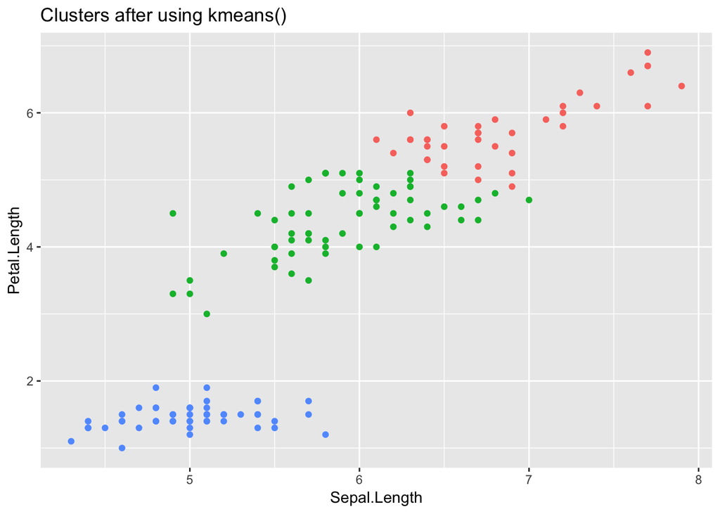

```r
data(iris)
iris_new <- iris[,1:4] # taking out the labeled data
c1 <- kmeans(x = iris_new, 3, nstart = 10)

a <- ggplot(data = iris_new) +
  geom_point(aes(x = Sepal.Length, y = Petal.Length, colour = factor(c1$cluster)), show.legend = FALSE) +
  labs(title = "Clusters after using kmeans()")
a
```

#### How does k-means clustering work?

Step 1: initialization: randomly assign class membership

```r
set.seed(12)
init <- sample(3, nrow(iris_new), replace = TRUE)
b <- ggplot(data = iris_new) +
  geom_point(aes(x = Sepal.Length, y = Petal.Length, colour = factor(init)), show.legend = FALSE) +
  labs(title = "k-means random initialization")
```

Step 2: iterate

1 Calculate the center of each subgroup as the average position of all observations in that subgroup. 2 Each observation is then assigned to the group of its nearest center.

It is also possible to stop the algorithm after a certain number of iterations, or once the centers move less than a certain distance:

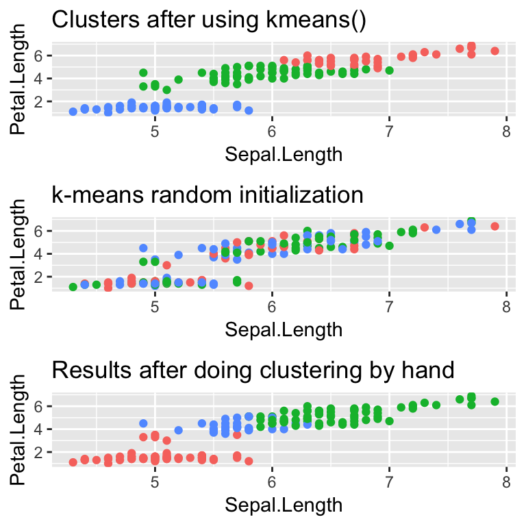

```r
centers <- sapply(1:3, function(i) colMeans(iris_new[init == i, ])) # creates a function that gathers the column mean for each column
centers <- t(centers) # transposes the results

tmp <- dist(rbind(centers, iris_new)) # dist() calculates the distance matrix
tmp <- as.matrix(tmp)[, 1:3] # converts the tmp into a matrix (keeps all rows and columms 1-3)
# it must be 3 columns because we picked 3 clusters earlier


# this one returns the column index where there is a minimum value and appplies does so for every row
# basically this finds out which cluster minimizes the distance between cluster and observation
ki <- apply(tmp, MARGIN = 1, FUN = which.min)
# margin = 1 applies function to row, margin = 2 applies function to columns.
# note: when MARGIN = c(1,2) it applies to both rows and columns


# gets rid of the first 3 rows (now it fits with the length of the iris_new length)
# I believe the first 3 is kind of like an identity matrix, which is why we got rid of them
ki <- ki[-(1:3)]

c <- ggplot(data = iris_new) +
  geom_point(aes(x = Sepal.Length, y = Petal.Length, colour = factor(ki)), show.legend = FALSE) +
  labs(title = "Results after doing clustering by hand")

gridExtra::grid.arrange(a, b, c)
```

#### Model Selection

Random initialization can lead to different clustering results. When k=means is run multiple times, the best outcome (the one with the smallest total within cluster sum of squares) is selected. The total within sum of squares is caculatd as, for each cluster, calculated the squared euclidean distance from observation to the center of the cluster for each observation. Total all distances.

That lowest within cluster sum of squares is called the local minimum, though we might not be able to get a global minimum.

Run multiple kmeans on the data with more than 1 iteration and see if you get the same reulsts:

```r
c2 <- kmeans(x = iris_new, 3, nstart = 10) # iteration = 10
c3 <- kmeans(x = iris_new, 3, nstart = 10)

# combining the results of the two clusters
table(c2$cluster, c3$cluster) # gives it different names, but same results
```

```
##
##      1  2  3
##   1 50  0  0
##   2  0  0 62
##   3  0 38  0
```

Now do the same with only 1 iteration:

```r
c4 <- kmeans(x = iris_new, 3, nstart = 1) # iteration = 10
c5 <- kmeans(x = iris_new, 3, nstart = 1)

# combining the results of the two clusters
table(c4$cluster, c5$cluster) # gives it different names, but same results
```

```
##
##      1  2  3
##   1  0  0 38
##   2  0 50  0
##   3 62  0  0
```

#### How to determine the number of clusters

Simple steps:

1 run k-means at different levels of clustering 2 Reocrd the toal within sum of squares for each clustering 3 CLoose k at the *elbow* position (imagine an arm, find the elbow and that is the best)

The elbow is kind of a soft rule. To me it seems like where you start getting real diminishing returns

Do clustering ranging from 1-10 and then plot them to spot the elbow:

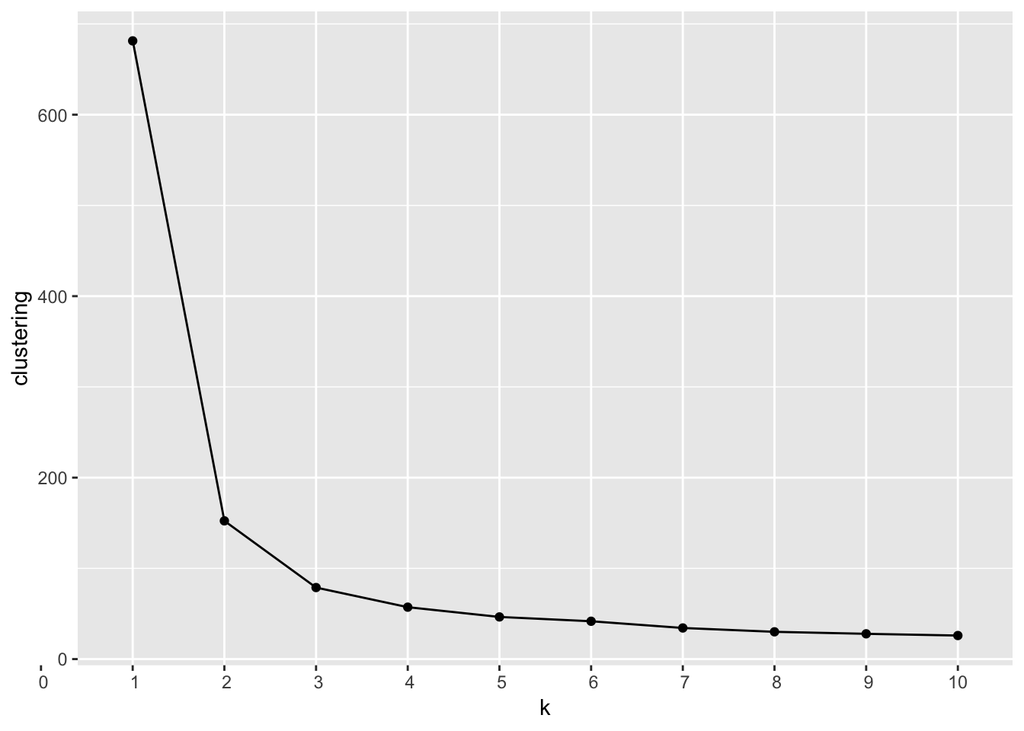

```r
k <- 1:10

clustering <- sapply(k, function(i) {
  cl <- kmeans(x = iris_new, i, nstart = 10)
  cl$tot.withinss
})

elbow <- cbind(k, clustering)
elbow <- as.data.frame(elbow)

ggplot(elbow) +
  geom_line(aes(x = k, y = clustering)) +
  geom_point(aes(x = k, y = clustering)) +
  scale_x_discrete(limits = c(0:10))
```

Looks like it could be 3 or 4 here (though we know that 3 is likely the best)

## Hierarchical Clustering

How does it work? First it starts by assigning each of the n point its own cluster. Then it iterates. FIrst it finds the two nearest clusters and joins the together. This leads to n-1 clusters. Then they continue merging clusters until all are grouped into a single cluster.

The results of hierarchical clustering are typically shown along with a dendogram wehre hte distance between the clusters is proportional to the branch length.

How to do this in R?

1 Calculate the distance using `dist`, typically the Euclidean distance. 2 Hierarchical clustering on this distance matrix using hclust

```r
iris_dist <- dist(iris[, 1:4])
hcl <- hclust(iris_dist)
hcl
```

```
##
## Call:
## hclust(d = iris_dist)
##
## Cluster method   : complete
## Distance         : euclidean
## Number of objects: 150
```

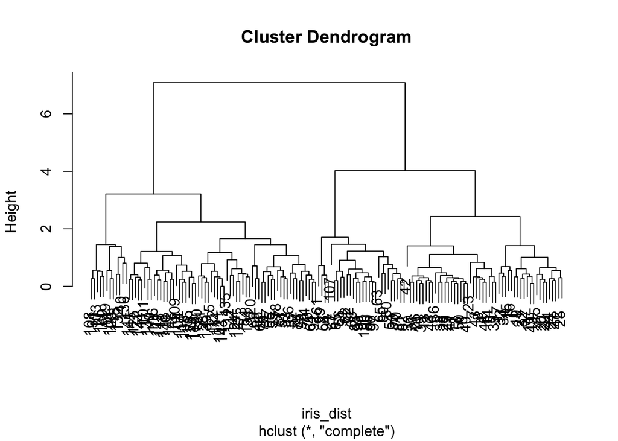

```r
plot(hcl)
```

After we have produced the results, we need to *cut the tree (dendogram)* at a specific heigh to define the clusters. In the example above, we could decide to cut

1 around a speicific height, like 1.5. 2 to get a certain number of clusters, k = 2 for instance

All of this is done with the cutree function

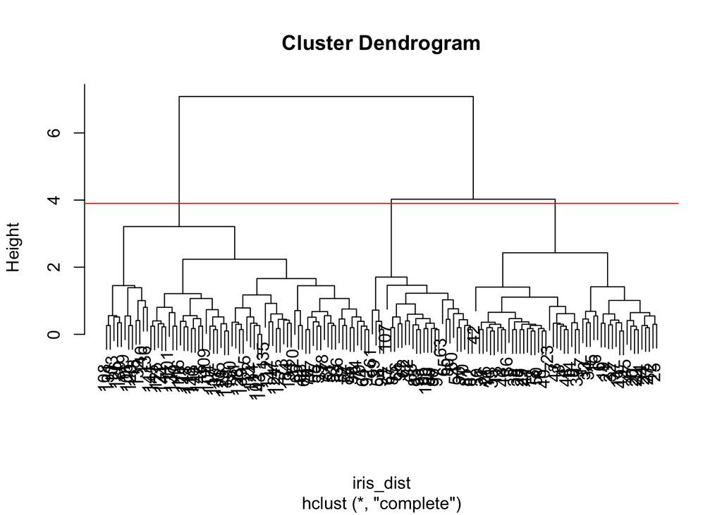

```r
plot(hcl)
abline(h = 3.9, col = "red")
```

```r
cutree(hcl, h = 3.9) # h = height
```

```
##   [1] 1 1 1 1 1 1 1 1 1 1 1 1 1 1 1 1 1 1 1 1 1 1 1 1 1 1 1 1 1 1 1 1 1 1 1
##  [36] 1 1 1 1 1 1 1 1 1 1 1 1 1 1 1 2 2 2 3 2 3 2 3 2 3 3 3 3 2 3 2 3 3 2 3
##  [71] 2 3 2 2 2 2 2 2 2 3 3 3 3 2 3 2 2 2 3 3 3 2 3 3 3 3 3 2 3 3 2 2 2 2 2
## [106] 2 3 2 2 2 2 2 2 2 2 2 2 2 2 2 2 2 2 2 2 2 2 2 2 2 2 2 2 2 2 2 2 2 2 2
## [141] 2 2 2 2 2 2 2 2 2 2
```

```r
cutree(hcl, k = 3) # k = number of clusters
```

```
##   [1] 1 1 1 1 1 1 1 1 1 1 1 1 1 1 1 1 1 1 1 1 1 1 1 1 1 1 1 1 1 1 1 1 1 1 1
##  [36] 1 1 1 1 1 1 1 1 1 1 1 1 1 1 1 2 2 2 3 2 3 2 3 2 3 3 3 3 2 3 2 3 3 2 3
##  [71] 2 3 2 2 2 2 2 2 2 3 3 3 3 2 3 2 2 2 3 3 3 2 3 3 3 3 3 2 3 3 2 2 2 2 2
## [106] 2 3 2 2 2 2 2 2 2 2 2 2 2 2 2 2 2 2 2 2 2 2 2 2 2 2 2 2 2 2 2 2 2 2 2
## [141] 2 2 2 2 2 2 2 2 2 2
```

```r
identical(cutree(hcl, h = 3.9), cutree(hcl, k = 3))
```

```
## [1] TRUE
```

Now, using the `k = 3` value, verify if k-means and hierarchical clustering produce the same results on the `iris` dataset.

```r
km <- kmeans(iris[,1:4], center = 3, nstart = 10)
hcl <- hclust(dist(iris[,1:4]))

table(km$cluster, cutree(hcl, k =3)) # get some difference with 2 and 3 groupings
```

```
##
##      1  2  3
##   1 50  0  0
##   2  0 34 28
##   3  0 38  0
```

Now let’s graph the two:

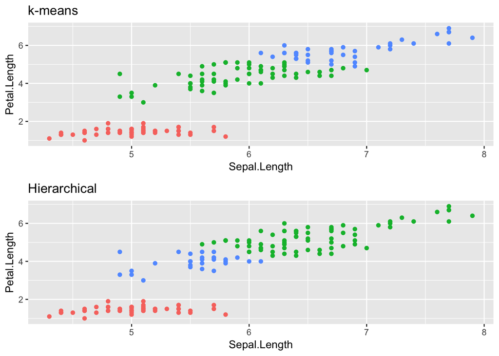

```r
d <- ggplot(data = iris) +
  geom_point(aes(x = Sepal.Length, y = Petal.Length, colour = factor(km$cluster)), show.legend = FALSE) +
  labs(title = "k-means")

e <- ggplot(data = iris) +
  geom_point(aes(x = Sepal.Length, y = Petal.Length, colour = factor(cutree(hcl, k = 3))), show.legend = FALSE)  +
  labs(title = "Hierarchical")

gridExtra::grid.arrange(d, e)
```

```r
table(iris$Species, km$cluster) # does really good with the first cluster, okay with vericolor, and not great with virginica
```

```
##
##               1  2  3
##   setosa     50  0  0
##   versicolor  0 48  2
##   virginica   0 14 36
```

```r
table(iris$Species, cutree(hcl, k = 3)) # this does really well with setosa and virginica, but poorly with veriscolor
```

```
##
##               1  2  3
##   setosa     50  0  0
##   versicolor  0 23 27
##   virginica   0 49  1
```

### Hierarchical v. K-means

There are obvious advantages for each one. K-means is generally faster than hierarchical clustering, for instance. My read of the profession, though, hierarchical clustering is is favored, all else equal. Hierarchical doesn’t require stating at the beginning how many clusters you want. You can decide after the fact. K-means also has a lot of assumptions about the distribution of the data, and is more sensitive to outliers.

## Pre-processing

Both unsupervised and supervised ML is sensitive to differnt scales. A typical way to pre-process the data is to scale it or apply principal component analysis (next section). Scaling means that all the columns will have a mean of 0 and a standard deviation of 1. Scaling can be done with the `scale` function.

Example: use the `scale` function to scale the data in mtcars. Run hierarchical clustering on both the original and the scaled to see how that changes the output.

```r
summary(mtcars) # definitely different means
```

```
##       mpg             cyl             disp             hp
##  Min.   :10.40   Min.   :4.000   Min.   : 71.1   Min.   : 52.0
##  1st Qu.:15.43   1st Qu.:4.000   1st Qu.:120.8   1st Qu.: 96.5
##  Median :19.20   Median :6.000   Median :196.3   Median :123.0
##  Mean   :20.09   Mean   :6.188   Mean   :230.7   Mean   :146.7
##  3rd Qu.:22.80   3rd Qu.:8.000   3rd Qu.:326.0   3rd Qu.:180.0
##  Max.   :33.90   Max.   :8.000   Max.   :472.0   Max.   :335.0
##       drat             wt             qsec             vs
##  Min.   :2.760   Min.   :1.513   Min.   :14.50   Min.   :0.0000
##  1st Qu.:3.080   1st Qu.:2.581   1st Qu.:16.89   1st Qu.:0.0000
##  Median :3.695   Median :3.325   Median :17.71   Median :0.0000
##  Mean   :3.597   Mean   :3.217   Mean   :17.85   Mean   :0.4375
##  3rd Qu.:3.920   3rd Qu.:3.610   3rd Qu.:18.90   3rd Qu.:1.0000
##  Max.   :4.930   Max.   :5.424   Max.   :22.90   Max.   :1.0000
##        am              gear            carb
##  Min.   :0.0000   Min.   :3.000   Min.   :1.000
##  1st Qu.:0.0000   1st Qu.:3.000   1st Qu.:2.000
##  Median :0.0000   Median :4.000   Median :2.000
##  Mean   :0.4062   Mean   :3.688   Mean   :2.812
##  3rd Qu.:1.0000   3rd Qu.:4.000   3rd Qu.:4.000
##  Max.   :1.0000   Max.   :5.000   Max.   :8.000
```

```r
mtcars_scaled <- scale(mtcars)

summary(mtcars_scaled)
```

```
##       mpg               cyl              disp               hp
##  Min.   :-1.6079   Min.   :-1.225   Min.   :-1.2879   Min.   :-1.3810
##  1st Qu.:-0.7741   1st Qu.:-1.225   1st Qu.:-0.8867   1st Qu.:-0.7320
##  Median :-0.1478   Median :-0.105   Median :-0.2777   Median :-0.3455
##  Mean   : 0.0000   Mean   : 0.000   Mean   : 0.0000   Mean   : 0.0000
##  3rd Qu.: 0.4495   3rd Qu.: 1.015   3rd Qu.: 0.7688   3rd Qu.: 0.4859
##  Max.   : 2.2913   Max.   : 1.015   Max.   : 1.9468   Max.   : 2.7466
##       drat               wt               qsec                vs
##  Min.   :-1.5646   Min.   :-1.7418   Min.   :-1.87401   Min.   :-0.868
##  1st Qu.:-0.9661   1st Qu.:-0.6500   1st Qu.:-0.53513   1st Qu.:-0.868
##  Median : 0.1841   Median : 0.1101   Median :-0.07765   Median :-0.868
##  Mean   : 0.0000   Mean   : 0.0000   Mean   : 0.00000   Mean   : 0.000
##  3rd Qu.: 0.6049   3rd Qu.: 0.4014   3rd Qu.: 0.58830   3rd Qu.: 1.116
##  Max.   : 2.4939   Max.   : 2.2553   Max.   : 2.82675   Max.   : 1.116
##        am               gear              carb
##  Min.   :-0.8141   Min.   :-0.9318   Min.   :-1.1222
##  1st Qu.:-0.8141   1st Qu.:-0.9318   1st Qu.:-0.5030
##  Median :-0.8141   Median : 0.4236   Median :-0.5030
##  Mean   : 0.0000   Mean   : 0.0000   Mean   : 0.0000
##  3rd Qu.: 1.1899   3rd Qu.: 0.4236   3rd Qu.: 0.7352
##  Max.   : 1.1899   Max.   : 1.7789   Max.   : 3.2117
```

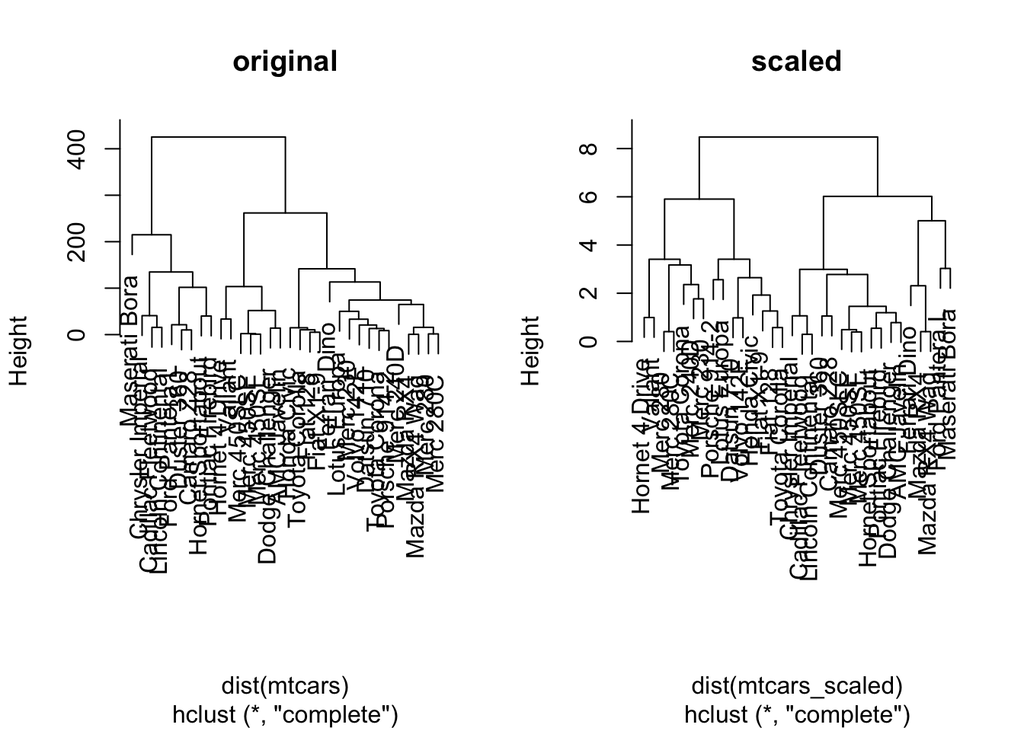

```r
mtcars_hcl <- hclust(dist(mtcars))


mtcars_scaled_hcl <- hclust(dist(mtcars_scaled))

par(mfrow = c(1, 2))
plot(mtcars_hcl, main = "original")
plot(mtcars_scaled_hcl, main = "scaled")
```

There are clear differences between the two. As the same suggests, pre-processing is done as a preliminary practice that will make later analysis more efficient. The method of scaling is only one way to pre-process the data (also called normalization). Other techniques includes data: cleaning, instance selection, transofrmation, feature extration, and selection. Cleaning is fixing bad values (i.e. men can’t be pregnant but the raw data may have that). Feature extraction will be covered more (I believe) in the Principal Components Analysis section.

## Principal Component Analysis (PCA)

PCA is widely used (and considered very versitile) that is used for: finding strucutre in features, pre-processing, and aiding in visualization. THe basic idea behind deminsionality reduction is to transform the data into a new space that “summarise properties of the whole dataset along a reduced number of dimensions. These are the nidela candidates to visualize the data laong these reduced number of informative dimensions.”

### How Does it work?

PCA is a technique that transofrms the original n-dimensional data into a new n-dimensional space.

- These new dimension are linear combinations of the original data (meaning they are composed of proportions of the original variables)
- Along tehse new dimensions, called **principal components**, the data expresses most of its variablility along the first PC, then second, …
- Principal components are orthogonal to each other (not correlated).

#### Example

using the iris data again, we can see that while it only contains 4 variables, it is already confusing to visualize the three groups along these dimensions (never mind the dozen+ variables that are common in research).

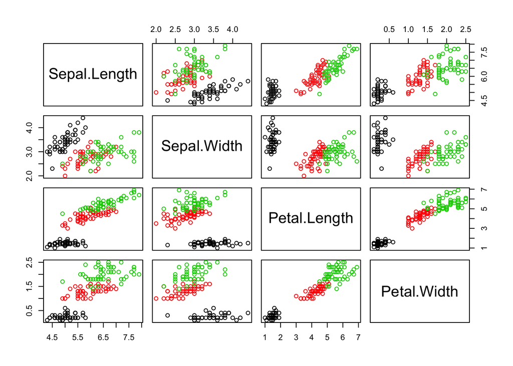

```r
plot(iris[, -5], col = iris$Species)
```

We can use `prcomp` to reduce the number of dimensions:

```r
iris_pca <- prcomp(iris[, -5]) # not doing this with the species variable

summary(iris_pca)
```

```
## Importance of components:
##                           PC1     PC2    PC3     PC4
## Standard deviation     2.0563 0.49262 0.2797 0.15439
## Proportion of Variance 0.9246 0.05307 0.0171 0.00521
## Cumulative Proportion  0.9246 0.97769 0.9948 1.00000
```

This summary shows us that along PC1 alone, we are able to retain 92% of hte total variability in the data.

Now we can visualize the results. A biplot shows all of hte original points re=mapped (rotated) along the first two PCs as well as the original features as vectors along the same PCs. Feature vectors that are in teh same idrection in PC space are also correlated in the original data space.

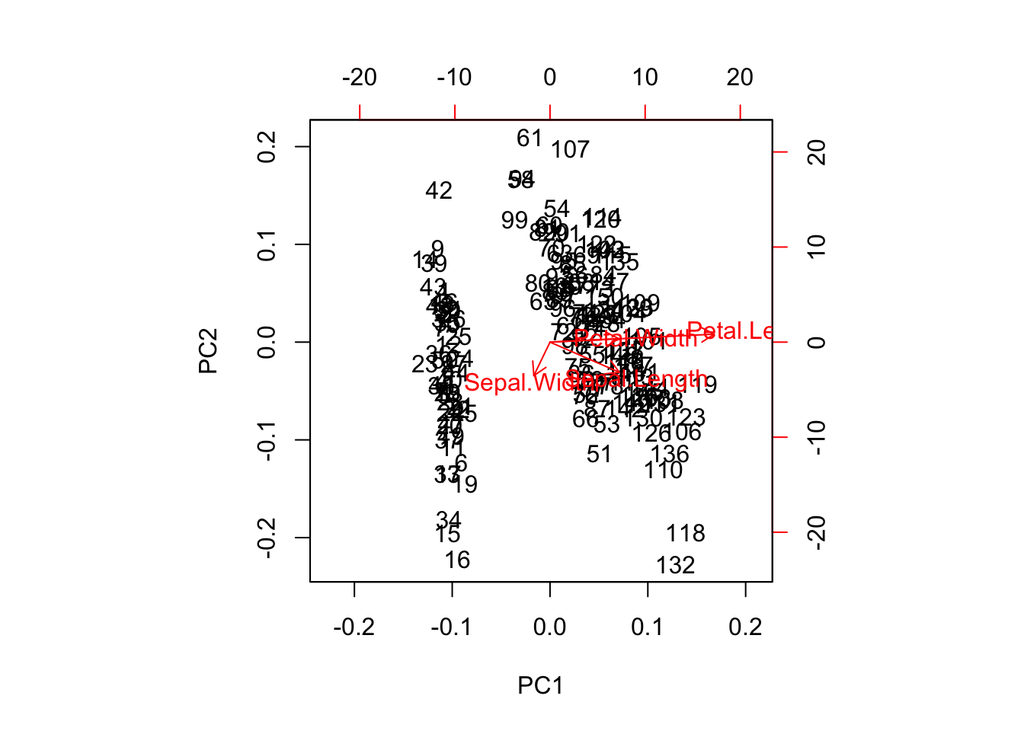

```r
biplot(iris_pca)
```

NOTE: one important piece of PCa is that proportion of vairance explained along the PCs, in particular when dealing with high dimensional data, as PC1 and PC2 (which are generally used for visualization), might only account for an insufficient proportion of variance to be relevant on their own.

We can extract the standard deviations from the PCA result to calculated the variances, then obtain a percentage of and cumulative variance along the PCs.

```r
var <- iris_pca$sdev^2

pve <- var/sum(var)
pve
```

```
## [1] 0.924618723 0.053066483 0.017102610 0.005212184
```

```r
cumsum(pve)
```

```
## [1] 0.9246187 0.9776852 0.9947878 1.0000000
```

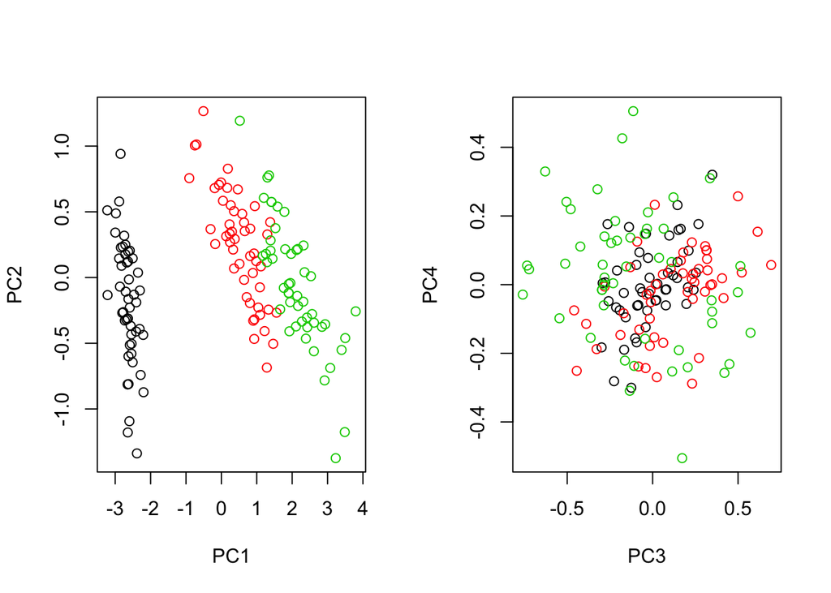

```r
par(mfrow = c(1, 2))
plot(iris_pca$x[, 1:2], col = iris$Species)
plot(iris_pca$x[, 3:4], col = iris$Species)
```

### Notes on PCA

PCA cannot deal with missing values which means it will simply drop those values. That may not be a problem if the proportion of missing data is small, but it should be considered. Second, be careful of using UML with categorical data because the computer will generally assume the interger provided to represent the category actually has some meaning (i.e., there is ordering and distance matters). You should either drop them before doing UML or create dummy variables.

## t-Distributed Stochastic Neighbor Embedding

The t-Distributed Stochastic Neighbour Embedding (t-SNE) is a non-linear dimensionality reduction technique, that different regions of the data space will be sujbected to different transformations. T-SNE will compress small distances, thus bringing close neighbr together, and will ignore distances. **It is particularly well suited for very high dimensional data**. t-SNE is especially popular in machine learning because it is very effective at creating impressive two-dimensional “maps” from data with hundreds or even thousands of dimensions, [see this link for more information](https://distill.pub/2016/misread-tsne/).

In R, we can use the `Rtsne` function from the `Rtsne` package. First, though, we have to remove any duplicates.

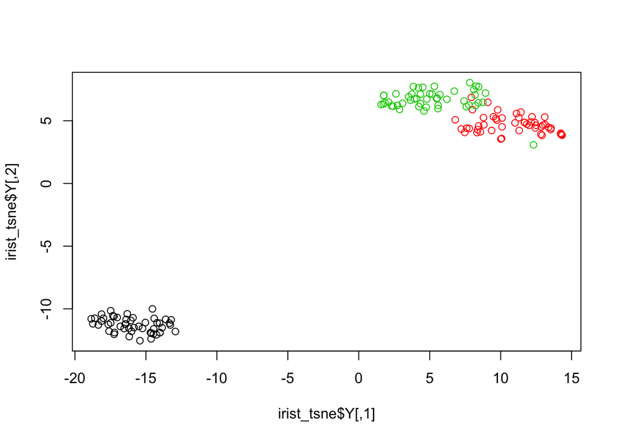

```r
library(Rtsne)

unique_iris <- unique(iris[, 1:5])

irist_tsne <- Rtsne(unique_iris[, 1:4])

plot(irist_tsne$Y, col = unique_iris$Species)
```

If we wanted to, we could have centered and scaled the data before running the t-SNE function (see the `pca_center` and `pca_scale` arguments). This algorithm is stochastic, and will producedifferent results for each repeition.

### Parameter tuning

While t-SNE is popular, it can be confusing to properly set and interpret the model. Part of this comes from the parameter tuining. t-SNE have two important parameters that can substantialy influence the clustering of data:

- Perplexity: balancing global and local aspects of the data
- Iterations: number of iterations before the clustering is stopped.

Let’s see what happens when we change these parameters a bit

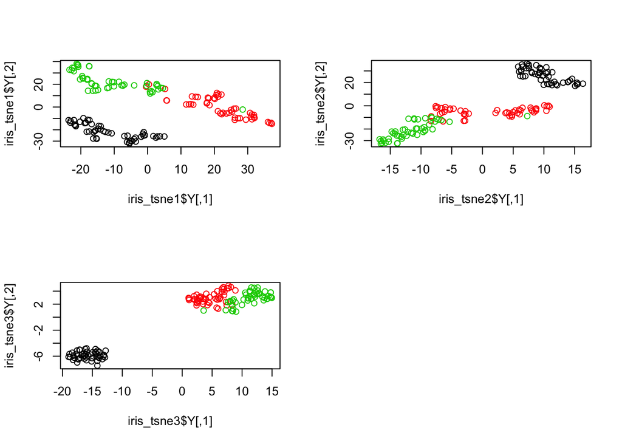

```r
iris_tsne1 <- Rtsne(unique_iris[, 1:4], perplexity = 5)
iris_tsne2 <- Rtsne(unique_iris[, 1:4], perplexity = 10)
iris_tsne3 <- Rtsne(unique_iris[, 1:4], perplexity = 30)

# different levels of perplexity
par(mfrow = c(2, 2))
plot(iris_tsne1$Y, col = unique_iris$Species)
plot(iris_tsne2$Y, col = unique_iris$Species)
plot(iris_tsne3$Y, col = unique_iris$Species)
```

Now that we have seen what happens when you change the perplexity, let’s see what happens when you change the number of iterations for the one that seemed to perform the best (perplexity of 30)

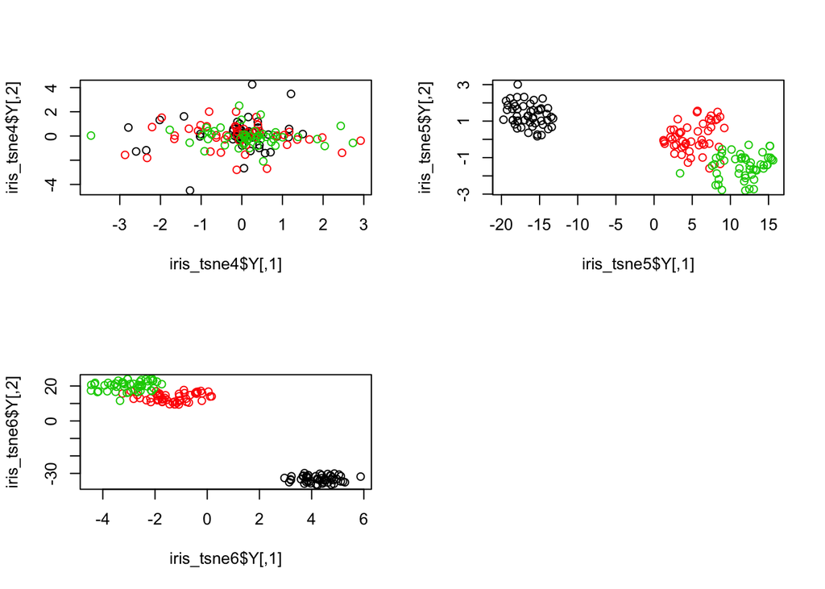

```r
iris_tsne4 <- Rtsne(unique_iris[, 1:4], perplexity = 30, max_iter = 10)
iris_tsne5 <- Rtsne(unique_iris[, 1:4], perplexity = 30, max_iter = 1000)
iris_tsne6 <- Rtsne(unique_iris[, 1:4], perplexity = 30, max_iter = 10000)

# different levels of perplexity
par(mfrow = c(2, 2))
plot(iris_tsne4$Y, col = unique_iris$Species)
plot(iris_tsne5$Y, col = unique_iris$Species)
plot(iris_tsne6$Y, col = unique_iris$Species)
```

An iteration of 10 is clearly not enough (the default is 1000), but the 1000 and 10000 ones seem to be pretty good. At this point it appears to be a matter of preference. Let’s try also applying `pca_center` and `pca_scale` to it (note: pca_center is true by default).

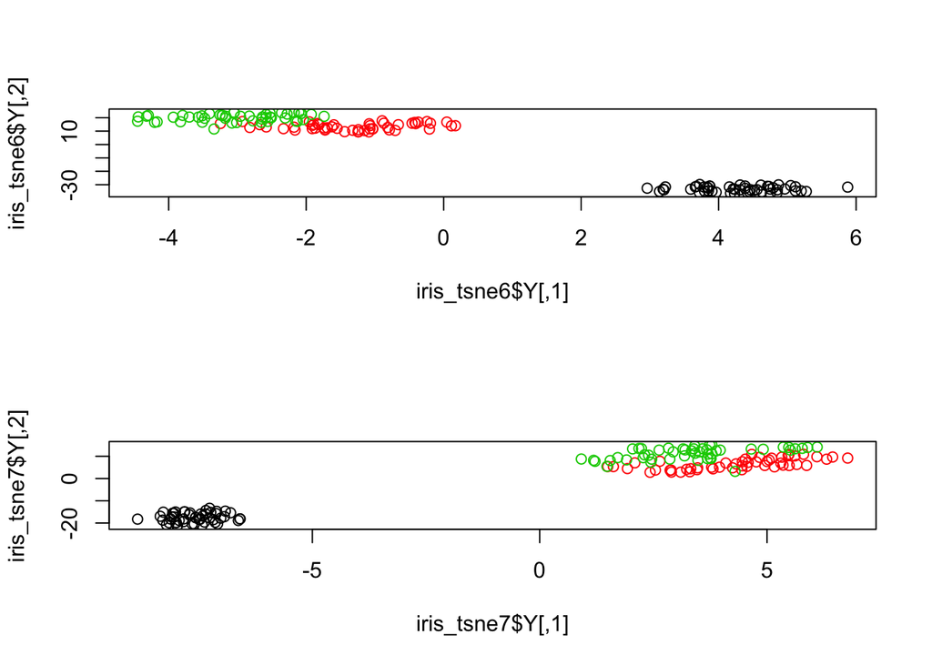

```r
iris_tsne7 <- Rtsne(unique_iris[, 1:4], perplexity = 30, max_iter = 10000, pca_center = TRUE, pca_scale = TRUE)

par(mfrow = c(2, 1))
plot(iris_tsne6$Y, col = unique_iris$Species)
plot(iris_tsne7$Y, col = unique_iris$Species)
```

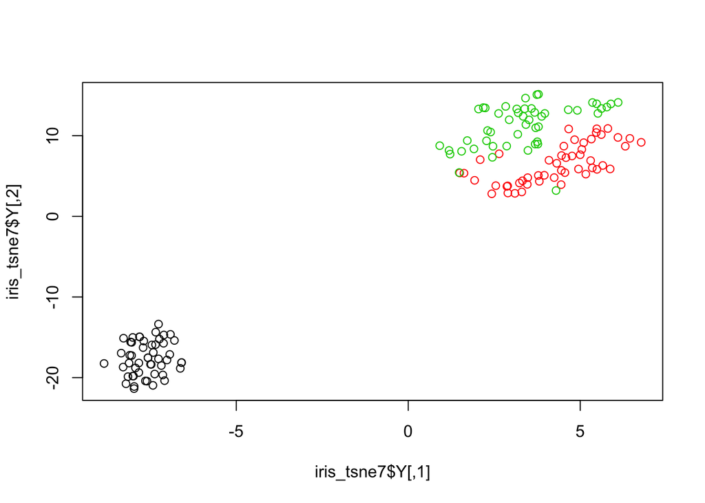

```r
plot(iris_tsne7$Y, col = unique_iris$Species)
```

## Supervised Learning

The difference between Unsupervised machine learning (UML) versus Supervised machine learning (SML) is that SML has labelled example inputs, which indicate the desired output (basically the DV). There are two main groups of Supervised Machine Learning:

- Classification: the output is qualitative
- Regression: the output is quantitative

### K nearest neighbors (kNN)

Let’s use a common SML algorithm, k nearest neighbors, to classify the iris flower dataset. To do this you will use the `knn` function from the class package. KNN works by directly measuring the euclidean distance beteen observations and infer the class of unlabelled data from teh class of its nearest neighbor.

In most ML processes there are two steps: train and predict. In KNN these two steps are combined into a single function called `knn`.

Let’s draw a set of 50 random iris observations to train the moel and predict the species of another set of 50 randomly chosen flowers. The `knn` function takes the training data, the new data (to be inferred) and the labels of the training data, and returns (be default) the predicted class.

```r
set.seed(12)

train <- sample(150, 50)
new <- sample(150, 50)

library("class")

knnres <- knn(iris[train, -5], iris[new, -5], iris$Species[train])
head(knnres)
```

```
## [1] versicolor versicolor versicolor setosa     versicolor virginica
## Levels: setosa versicolor virginica
```

Now we can compare the observed KNN-predicted class and the expected known outcome and calculate the over accuracy of the model.

```r
table(knnres, iris$Species[new])
```

```
##
## knnres       setosa versicolor virginica
##   setosa         18          0         0
##   versicolor      0         18         1
##   virginica       0          1        12
```

```r
mean(knnres == iris$Species[new])
```

```
## [1] 0.96
```

Both of these show that the model does a pretty great job of classifying the data.

One key argument we have omitted from hte `knn` function is the parameter *k*. The value *k* defines how many nearest neighbors will be considered to assign a class to a new unlabelled observation. We can look at the arguments for a function by doing the following:

```r
args(knn)
```

```
## function (train, test, cl, k = 1, l = 0, prob = FALSE, use.all = TRUE)
## NULL
```

As we can see, the default for *k* is 1. But is this a good value? Would we prefer to look at more neighbors and infer the new clas using a vote based on more lables?

#### Challenge

run the knn again but with a different value for k. Use the same data as before to avoid any biases in comparison

```r
knnres_2 <- knn(iris[train, -5], iris[new, -5], iris$Species[train], k = 5)
```

Now let’s see how this new model did compared to the old.

```r
table(knnres_2, iris$Species[new])
```

```
##
## knnres_2     setosa versicolor virginica
##   setosa         18          0         0
##   versicolor      0         17         1
##   virginica       0          2        12
```

```r
mean(knnres_2 == iris$Species[new])
```

```
## [1] 0.94
```

A k = 5 did slightly worse than our k = 1. Now lets try the same model, but with a `prob = TRUE` to obtain the proportion of the votes for the winning class:

```r
knnres_3 <- knn(iris[train, -5], iris[new, -5], iris$Species[train], k = 5, prob = TRUE)

table(attr(knnres_3, "prob"))
```

```
##
## 0.6 0.8   1
##   4   1  45
```